# 06 - EDA Correlation Structure

## 1 Objective

This report provides a focused correlation analysis for the BodyFat dataset after removing `Density` (a leakage variable).

It includes: 1. A single-row heatmap of each predictor’s Pearson correlation with `BodyFat`. 2. Side-by-side scatter plots for the top 5 predictors by absolute correlation with `BodyFat`, with trend lines, 95% confidence bands, and `r` annotations. 3. A hierarchically clustered full correlation heatmap across all remaining numeric features, plus cluster membership labels. 4. Discussion of multicollinearity risks for linear models and implications for tree-based models.

## 2 Setup and Data

```r
library(tidyverse)

bodyfat_raw <- read_csv("data/bodyfat.csv", show_col_types = FALSE)

# Remove leakage variable before correlation analysis
bodyfat <- bodyfat_raw %>%
  select(-Density)

predictor_names <- setdiff(names(bodyfat), "BodyFat")

corr_target <- map_dfr(predictor_names, function(v) {
  tibble(
    Predictor = v,
    r = cor(bodyfat[[v]], bodyfat$BodyFat, use = "complete.obs")
  )
}) %>%
  mutate(abs_r = abs(r)) %>%
  arrange(desc(abs_r))

corr_target
```

```
# A tibble: 13 × 3
   Predictor       r  abs_r
   <chr>       <dbl>  <dbl>
 1 Abdomen    0.813  0.813
 2 Chest      0.703  0.703
 3 Hip        0.625  0.625
 4 Weight     0.612  0.612
 5 Thigh      0.560  0.560
 6 Knee       0.509  0.509
 7 Biceps     0.493  0.493
 8 Neck       0.491  0.491
 9 Forearm    0.361  0.361
10 Wrist      0.347  0.347
11 Age        0.291  0.291
12 Ankle      0.266  0.266
13 Height    -0.0895 0.0895
```

## 3 Predictor vs BodyFat Correlation Heatmap (Single Row)

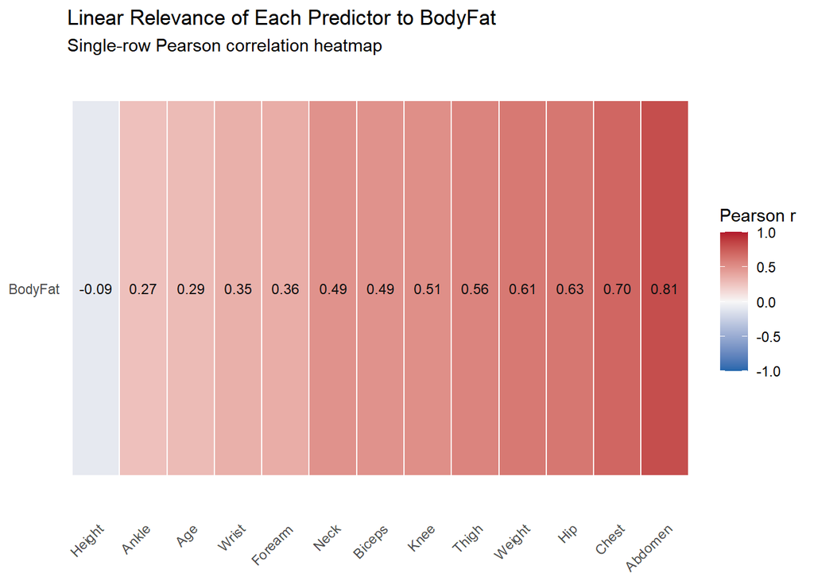

```r
heatmap_target <- corr_target %>%
  mutate(Predictor = fct_reorder(Predictor, r))

p_target_heatmap <- ggplot(heatmap_target, aes(x = Predictor, y = "BodyFat", fill = r)) +
  geom_tile(color = "white", linewidth = 0.4) +
  geom_text(aes(label = sprintf("%.2f", r)), size = 3.1, color = "#111111") +
  scale_fill_gradient2(
    low = "#2166AC",
    mid = "#F7F7F7",
    high = "#B2182B",
    midpoint = 0,
    limits = c(-1, 1)
  ) +
  labs(
    title = "Linear Relevance of Each Predictor to BodyFat",
    subtitle = "Single-row Pearson correlation heatmap",
    x = NULL,
    y = NULL,
    fill = "Pearson r"
  ) +
  theme_minimal(base_size = 11) +
  theme(
    axis.text.x = element_text(angle = 45, hjust = 1),
    panel.grid = element_blank()
  )

p_target_heatmap
```

## 4 Top 5 Predictors: Scatter Plots with Trend Lines

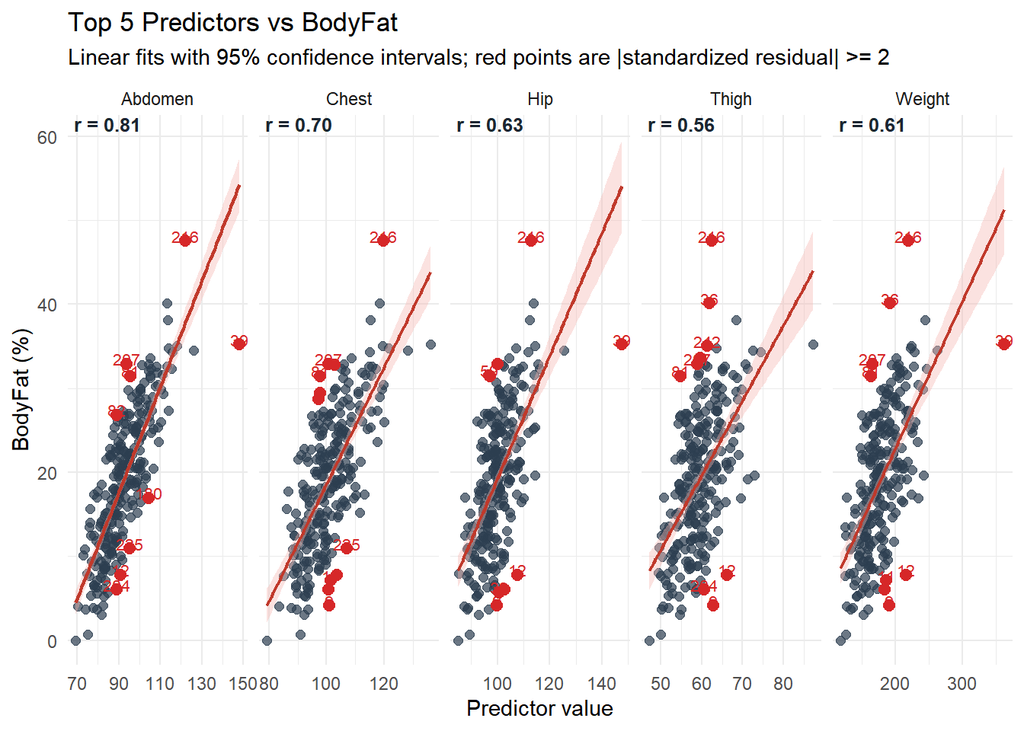

```r
top5 <- corr_target %>%
  slice_head(n = 5)

top5_long <- bodyfat %>%
  mutate(row_id = row_number()) %>%
  select(row_id, BodyFat, all_of(top5$Predictor)) %>%
  pivot_longer(
    cols = all_of(top5$Predictor),
    names_to = "Predictor",
    values_to = "Value"
  )

# Compute per-predictor standardized residuals to flag points far from the linear trend
outlier_points <- top5_long %>%
  group_by(Predictor) %>%
  group_modify(~ {
    fit <- lm(BodyFat ~ Value, data = .x)
    .x %>%
      mutate(std_resid = as.numeric(rstandard(fit))) %>%
      filter(abs(std_resid) >= 2)
  }) %>%
  ungroup()

r_labels <- top5 %>%
  transmute(Predictor, label = paste0("r = ", sprintf("%.2f", r)))

p_top5 <- ggplot(top5_long, aes(x = Value, y = BodyFat)) +
  geom_point(alpha = 0.7, color = "#2C3E50", size = 1.9) +
  geom_smooth(method = "lm", se = TRUE, color = "#C0392B", fill = "#F5B7B1", linewidth = 0.8) +
  geom_point(
    data = outlier_points,
    aes(x = Value, y = BodyFat),
    inherit.aes = FALSE,
    color = "#D62728",
    size = 2.5
  ) +
  geom_text(
    data = outlier_points,
    aes(x = Value, y = BodyFat, label = row_id),
    inherit.aes = FALSE,
    nudge_y = 0.6,
    size = 2.8,
    color = "#D62728",
    check_overlap = TRUE
  ) +
  geom_text(
    data = r_labels,
    aes(x = -Inf, y = Inf, label = label),
    inherit.aes = FALSE,
    hjust = -0.1,
    vjust = 1.1,
    size = 3.3,
    fontface = "bold",
    color = "#1B2631"
  ) +
  facet_wrap(~ Predictor, scales = "free_x", nrow = 1) +
  labs(
    title = "Top 5 Predictors vs BodyFat",
    subtitle = "Linear fits with 95% confidence intervals; red points are |standardized residual| >= 2",
    x = "Predictor value",
    y = "BodyFat (%)"
  ) +
  theme_minimal(base_size = 11)

p_top5
```

```r
outlier_summary <- outlier_points %>%
  arrange(Predictor, desc(abs(std_resid))) %>%
  group_by(Predictor) %>%
  summarise(
    flagged_rows = paste(row_id, collapse = ", "),
    max_abs_std_resid = round(max(abs(std_resid)), 2),
    .groups = "drop"
  )

outlier_summary
```

```
# A tibble: 5 × 3
  Predictor flagged_rows                                   max_abs_std_resid
  <chr>     <chr>                                                      <dbl>
1 Abdomen   39, 207, 204, 12, 81, 225, 82, 216, 180                     4.13
2 Chest     216, 9, 81, 207, 12, 204, 11, 225, 138, 208, 5              2.56
3 Hip       39, 216, 12, 204, 9, 59, 81, 32, 207                        3.18
4 Thigh     216, 36, 9, 12, 81, 249, 204, 207, 242                      3.69
5 Weight    216, 36, 12, 39, 9, 207, 81, 204, 11                        3.24
```

Interpretation: - The top predictors typically show strong positive and near-linear association with `BodyFat`. - Red labels identify observations that deviate most strongly from each fitted line and may deserve quality checks or robust-model sensitivity analysis.

## 5 Full Hierarchically Clustered Correlation Heatmap

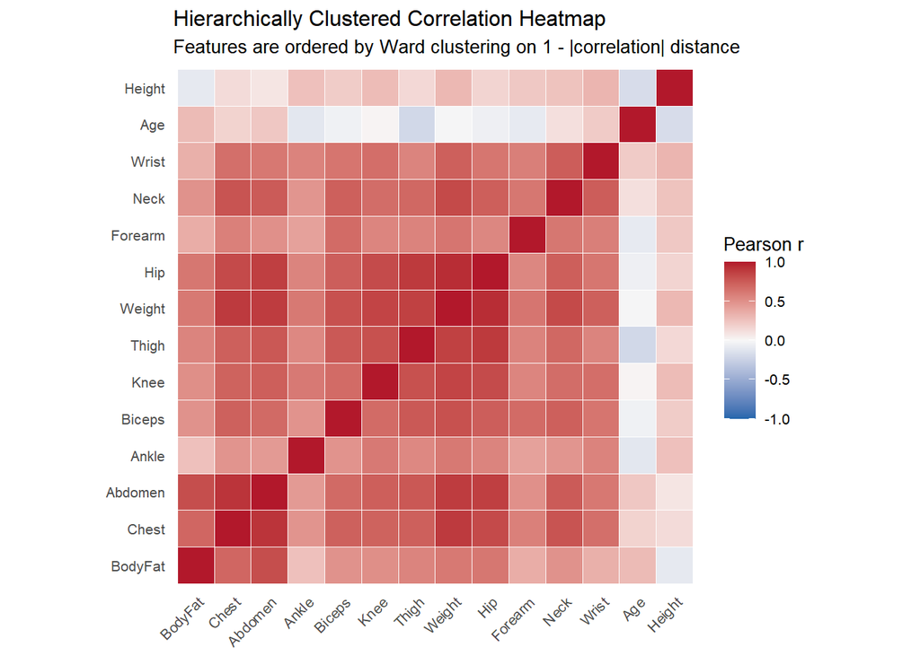

```r
features_all <- bodyfat %>% select(where(is.numeric))

cor_full <- cor(features_all, use = "pairwise.complete.obs")

# Cluster by absolute-correlation similarity so highly related measurements are adjacent
distance_matrix <- as.dist(1 - abs(cor_full))
hc <- hclust(distance_matrix, method = "ward.D2")
ordered_features <- colnames(cor_full)[hc$order]

cor_ordered <- cor_full[ordered_features, ordered_features]

cor_long <- as.data.frame(as.table(cor_ordered)) %>%
  as_tibble() %>%
  rename(Feature1 = Var1, Feature2 = Var2, Correlation = Freq)

p_full_heatmap <- ggplot(cor_long, aes(x = Feature1, y = Feature2, fill = Correlation)) +
  geom_tile(color = "white", linewidth = 0.25) +
  scale_fill_gradient2(
    low = "#2166AC",
    mid = "#F7F7F7",
    high = "#B2182B",
    midpoint = 0,
    limits = c(-1, 1)
  ) +
  labs(
    title = "Hierarchically Clustered Correlation Heatmap",
    subtitle = "Features are ordered by Ward clustering on 1 - |correlation| distance",
    x = NULL,
    y = NULL,
    fill = "Pearson r"
  ) +
  theme_minimal(base_size = 10) +
  theme(
    axis.text.x = element_text(angle = 45, hjust = 1, vjust = 1),
    panel.grid = element_blank()
  ) +
  coord_equal()

p_full_heatmap
```

```r
# Label natural groups from hierarchical clustering
cluster_assign <- cutree(hc, k = 4)

cluster_membership <- tibble(
  Feature = names(cluster_assign),
  Cluster = paste0("Cluster ", cluster_assign)
) %>%
  arrange(Cluster, Feature)

cluster_summary <- cluster_membership %>%
  group_by(Cluster) %>%
  summarise(Features = paste(Feature, collapse = ", "), .groups = "drop")

cluster_summary
```

```
# A tibble: 4 × 2
  Cluster   Features
  <chr>     <chr>
1 Cluster 1 Abdomen, BodyFat, Chest
2 Cluster 2 Age
3 Cluster 3 Ankle, Biceps, Forearm, Hip, Knee, Neck, Thigh, Weight, Wrist
4 Cluster 4 Height
```

Interpretation: - Clusters usually reflect anatomically related regions (for example, torso circumferences together, limb measures together, and global size variables such as `Weight`). - Strong within-cluster correlation indicates substantial predictor redundancy.

## 6 Multicollinearity Discussion

- Many circumference variables measure overlapping body-size information, so high pairwise correlations are expected and visible in the clustered heatmap.
- In linear regression, strong multicollinearity can inflate coefficient variance, making slope estimates unstable and sensitive to small data perturbations.
- This instability affects interpretation more than pure prediction: coefficients may flip sign or become statistically weak despite useful combined predictive signal.
- Regularized linear models (ridge, lasso, elastic net) can help stabilize estimation by shrinking coefficients and handling redundancy.
- Tree-based models (random forests, gradient boosting) are generally less sensitive to linear multicollinearity for predictive accuracy because they split recursively and can use one of several correlated features interchangeably.
- However, correlated predictors can still spread feature importance across variables in tree ensembles, so importance rankings should be interpreted with caution.

## 7 Conclusion

The correlation structure confirms that central body-size predictors are most linearly informative for `BodyFat`, with clear redundancy among related measurements. This supports using multicollinearity-aware linear approaches for interpretability and tree-based ensembles for robust predictive performance.